# MATH-257 - Lab #3 - Linear Regression

### Inference and Predictions

After verifying that the Normal probability distribution is appropriate, we can engage in *statistical inference*. For linear regression, there are two broad types of inference we might be interested in:

1. **Parameter estimation** - evaluating the statistical uncertainty of our least squares estimates using *confidence intervals* and/or *hypothesis testing*
2. **Prediction** - using our model to make predictions about new data using *prediction intervals*

These inferences are based upon the errors following a $N(0,\sigma^2)$ distribution. However, because we must estimate $\sigma^2$ in order to determine the *standard errors* of our model parameters, hypothesis tests and confidence intervals should use the $t$-distribution. We will not cover the details, but for *simple linear regression* the degrees of freedom are $n - 2$ when conducting inference on the model’s slope or intercept.

You can find more information regarding the *sampling distribution* of $\beta_1$ in Chapter 3.6 of our textbook, A Second Course in Statistics. For our purposes, we’ll rely upon `R` to obtain the standard errors of these estimates using the `summary` function. Recall that we can also obtain confidence intervals using the `confint` function.

```r
## Model summary (estimates, std errors, and t-tests)
summary(model)
```

```
##
## Call:
## lm(formula = sale.amount ~ assessed, data = ic)
##
## Residuals:
##     Min      1Q  Median      3Q     Max
## -152050   -7137    -347    7496  148286
##
## Coefficients:
##               Estimate Std. Error t value Pr(>|t|)
## (Intercept) -1.523e+00  1.712e+03  -0.001    0.999
## assessed     1.033e+00  8.819e-03 117.142   <2e-16 ***
## ---
## Signif. codes:  0 '***' 0.001 '**' 0.01 '*' 0.05 '.' 0.1 ' ' 1
##
## Residual standard error: 20970 on 775 degrees of freedom
## Multiple R-squared:  0.9465, Adjusted R-squared:  0.9465
## F-statistic: 1.372e+04 on 1 and 775 DF,  p-value: < 2.2e-16
```

```r
## Confidence interval estimates
confint(model)
```

```
##                    2.5 %     97.5 %
## (Intercept) -3361.652060 3358.60640
## assessed        1.015815    1.05044
```

Predictions can be found using the `predict` function, with prediction intervals stemming from the argument `interval = "prediction`. It is often useful to setup a “grid” of x-values that encompass the entire range of the explanatory variable when looking at prediction intervals.

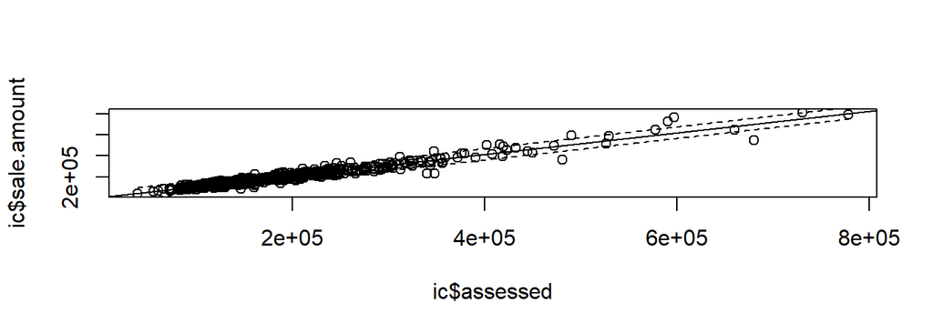

```r
## Setup a grid of x-values to predict over
xgrid <- data.frame(assessed = seq(min(ic$assessed), max(ic$assessed), length.out = 1000))

## Use "predict" to get model-based predictions and prediction intervals
preds <- predict(model, newdata = xgrid, interval = "prediction", level = .99)

## Base R plotting
plot(ic$assessed, ic$sale.amount) ## Scatterplot
abline(a = model$coefficients[1], b = model$coefficients[2]) ## Line equation
lines(xgrid$assessed, preds[,2], lty = 2)  ## Prediction lower band
lines(xgrid$assessed, preds[,3], lty = 2)  ## Prediction upper band

## ggplot version
library(ggplot2)
```

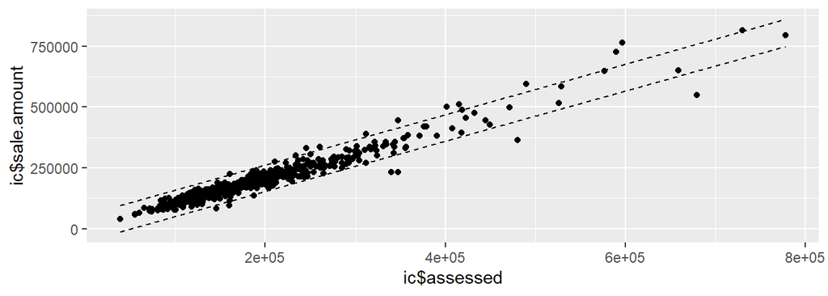

```r
ggplot() + geom_point(aes(x = ic$assessed, y = ic$sale.amount)) +
           geom_line(aes(x = xgrid$assessed, y = preds[,2]), linetype = "dashed") +
           geom_line(aes(x = xgrid$assessed, y = preds[,3]), linetype = "dashed")
```

The graphs generated by the code above display 99% prediction intervals, implying that the actual y-value for 99% of data-points should be within these limits. Recognize that *prediction intervals* are fundamentally different from *confidence intervals*. The former deals with the uncertainty involved in predicting *individual observations*, while the later deals with the uncertainty involved in *estimating model parameters*.

**Question #8**: Using the model you fit in Question #4 that relates “TotBill” and “Tip”, create a graph showing the 95% prediction bands. Does it appear that 95% of the data falls inside of these bands?

$~$

## Practice

**Question #9**: For this question you will conduct a comprehensive analysis using the data introduced below by following the steps outlines in Parts A-H.

The [Armed Forces Qualification Test (AFQT)](https://en.wikipedia.org/wiki/Armed_Services_Vocational_Aptitude_Battery) is a multiple choice aptitude test designed to gauge whether an individual’s reasoning and verbal skills are sufficient for military service. Because the test has been so broadly applied, scores are reported as percentiles and are frequently used as a measure of general intelligence.

The data you will use in the questions that follow comes from a random sample of 2584 Americans who were first selected and tested in 1979, then later re-interviewed in 2006 and asked about their education and annual income. Your focus will be on using AFQT percentile scores (`AFQT`) to model annual income (`Income2005`)

```r
## Load the data
afqt <- read.csv("https://remiller1450.github.io/data/AFQT.csv")
```

- **Part A**: Write code that reads the data, then use the `summary` function to check for any missing values in the variables `AFQT` and `Income2005`.
- **Part B**: Create a histogram of the variable `Income2005`, is the distribution of this variable skewed or symmetric?
- **Part C**: Fit a linear regression model that uses `AFQT` to predict `Income2005` and report the least squares estimates using proper notation.
- **Part D**: Use the `plot` function to evaluate the assumptions of this model. Do you believe inference using this model is statistically valid, or are the model’s assumptions violated assumptions?
- **Part E**: Create a new variable that is base-2 logarithm of `Income2005`, is the distribution of this new variable skewed or symmetric?
- **Part F**: Fit a linear regression model using the new variable you created in Part E as the outcome (keeping `AFQT` as the predictor). Then use the `plot` function to evaluate the assumptions of this model. Based upon what you see, do you believe this model is better suited for valid statistical inference than the model you explored in Part D?
- **Part G**: Interpret the slope of the model you fit in Part F. Additionally, use a hypothesis test to determine whether there is a statistically significant association between `AFQT` percentiles and future income.
- **Part H**: Using the model you fit in Part F, report the 99% prediction interval for an individual with a 99th percentile AFQT score. Be careful to report in your interval in dollars, not log-2 dollars!